# Run AtacAnnoR step by step

Lejin Tian

2023-03-06

In this tutorial, you can run AtacAnnoR step by step to see how AtacAnnoR works and modify parameters to annotate scATAC-seq cells better.

## Load required packages and datasets

```r
library(AtacAnnoR)
library(Seurat)
setwd('~/txmdata/scATAC_seq/AtacAnnoR')
SeuratObj_RNA <- readRDS('./data/10X-Multiome/SeuratObj/SeuratObj_RNA.RDS')    # reference
SeuratObj_ATAC <- readRDS('./data/10X-Multiome/SeuratObj/SeuratObj_ATAC.RDS')    # query
```

## Preprocessing reference and query data

Preprocessing of scATAC-seq data in AtacAnnoR includes two steps:

#### Gene-level signal extraction: gene activity matrix

Gene activity was previously calculated by `Signac::Geneactivity()` and saved in ‘ACTIVITY’ assay of the Seurat object `SeuratObj_ATAC`, for details about calculating gene activity, see https://stuartlab.org/signac/reference/geneactivity. You can also calculate gene activity matrix using other models, like [ArchR](https://www.archrproject.com/bookdown/calculating-gene-scores-in-archr.html), [Cicero](https://cole-trapnell-lab.github.io/cicero-release/docs_m3/#cicero-gene-activity-scores), [MAESTRO](https://baigal628.github.io/MAESTRO_documentation/scatac_stepbystep.html), etc.

#### Genome-wide-level signal extraction: meta-program matrix

Meta-program matrix can be calculated using `get_nmf_embedding()` function in AtacAnnoR, and the default factor number is set to 50.

```r
query_nmf_embedding <- get_nmf_embedding(peak_counts = SeuratObj_ATAC[['ATAC']]@counts,n_factors = 50)
```

```
## Performing TF-IDF normalization...
```

```
## Performing NMF...
```

We next keep the common features of reference and query.

```r
pre_processing_mtxs <- pre_processing(ref_mtx = SeuratObj_RNA[['RNA']]@counts,
                                      query_mtx = SeuratObj_ATAC[['ACTIVITY']]@counts,
                                      verbose = T)
```

```
## Keep 16523 intersect genes
```

```r
ref_mtx <- pre_processing_mtxs$ref_mtx
query_mtx <- pre_processing_mtxs$query_mtx
```

## First round annotation

In the first round annotation, AtacAnnoR performs a gene-level annotation and select a fraction of cells as seed cell candidates.

### Step 1: Identification of reference cell type-specific marker genes

In addition to the conventional marker genes (referred to as **global marker** genes here), we also identify the neighbor marker genes for a reference cell type that distinguish it from closely related adjacent cell types.

```r
global_markers <- get_global_markers_sc(sc_counts_mtx = ref_mtx,
                                        labels = SeuratObj_RNA$true,
                                        max_marker = 200)
neighbor_celltypes <- get_neighbor_celltypes(sc_count_mtx = ref_mtx,
                                             labels = SeuratObj_RNA$true,
                                             global_markers,
                                             min_cor = 0.6)
```

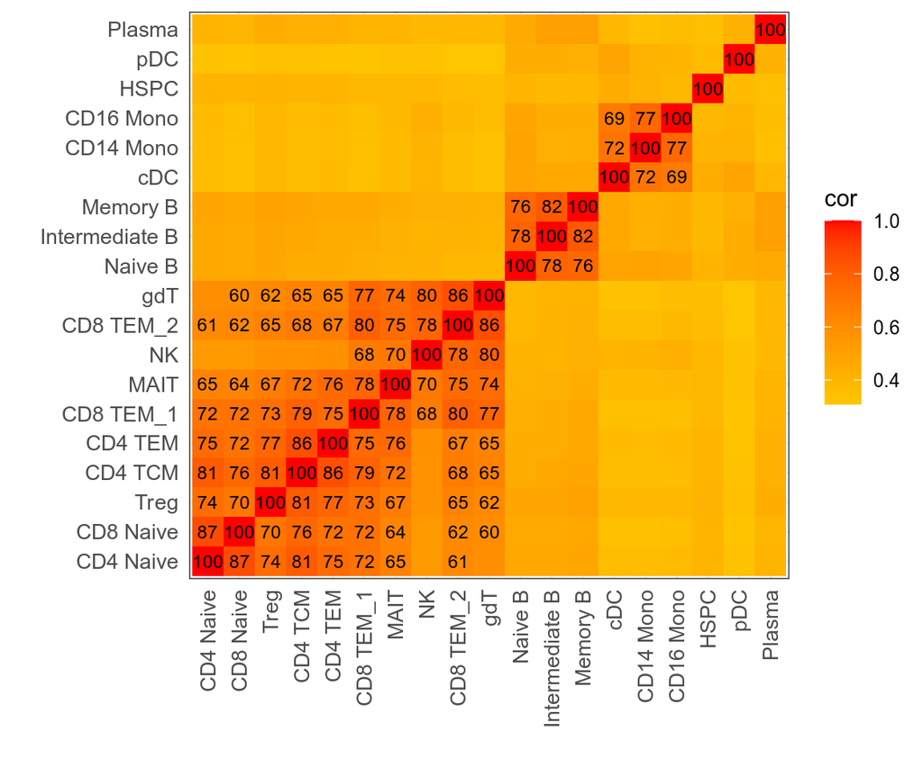

```r
neighbor_markers <- get_neighbor_markers_sc(sc_counts_mtx = ref_mtx,
                                            labels = SeuratObj_RNA$true,
                                            neighbor_celltypes = neighbor_celltypes,
                                            global_markers = global_markers)
```

### Step 2: Determination of candidate cell type labels for each query cell

This is done by calculating the Kendall’s tau between each query cell’s gene activity profile and each reference cell type’s gene expression profile, and the candidate cell label is determined by selecting the most similar reference cell type. The predicted labels are saved in `cell_meta$kendall_pred`.

```r
cor_mtx <- get_cor_mtx(sc_count_mtx = ref_mtx,
                       labels = SeuratObj_RNA$true,
                       query_mtx = query_mtx,
                       global_markers = global_markers,
                       query_nmf_embedding = query_nmf_embedding)
```

```
## Processing reference...
```

```
## Processing query...
```

```
## Intersect genes number: 690
```

```
## Computing Kendall correlation coefficient using 10 threads...
```

```r
cell_meta <- get_kendall_pred(cor_mtx)
cell_meta <- get_cell_meta_with_true(cell_meta,SeuratObj_ATAC$true,cor_mtx)    # add the true label column
get_benchmark(cell_meta$true,cell_meta$kendall_pred)
```

```
##          accuracy    average_recall average_precision          macro_f1
##         0.8195352         0.7533945         0.8185399         0.7558382
```

### Step 3: Validation of candidate cell type labels

This step is done by testing whether the marker genes are of higher activity than the background genes using statistical test, which result in two scores: global marker significant score(GMSS) and neighbor marker significant score(NMSS). Then, the seed cell candidates are selected by choosing those cells with high scores using Gaussian Mixture Model (GMM).

```r
cell_meta <- test_markers(query_mtx,cell_meta,global_markers,neighbor_markers,threads = 10,verbose = T)
```

```
## Start testing markers using 10 threads...
```

```r
cell_meta <- get_seed_candidates(cell_meta)
seed_candidate_meta <- cell_meta[which(cell_meta$is_seed_candidate == T),]
get_benchmark(seed_candidate_meta$true,seed_candidate_meta$kendall_pred)    # seed cell candidates accuracy
```

```
##          accuracy    average_recall average_precision          macro_f1
##         0.9584360         0.9157778         0.9500113         0.9243800
```

`AtacAnnoR:::plot_cell_distribution()` can be used to plot the distribution of GMSS and NMSS for one predicted cell type.

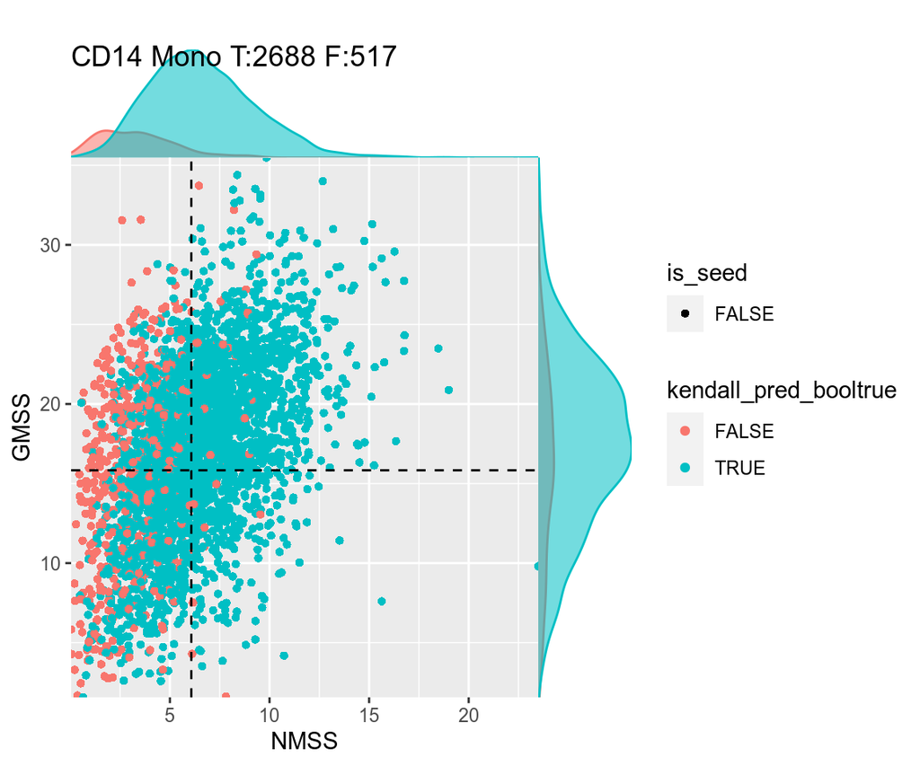

```r
AtacAnnoR:::plot_cell_distribution(cell_meta,'CD14 Mono')
```

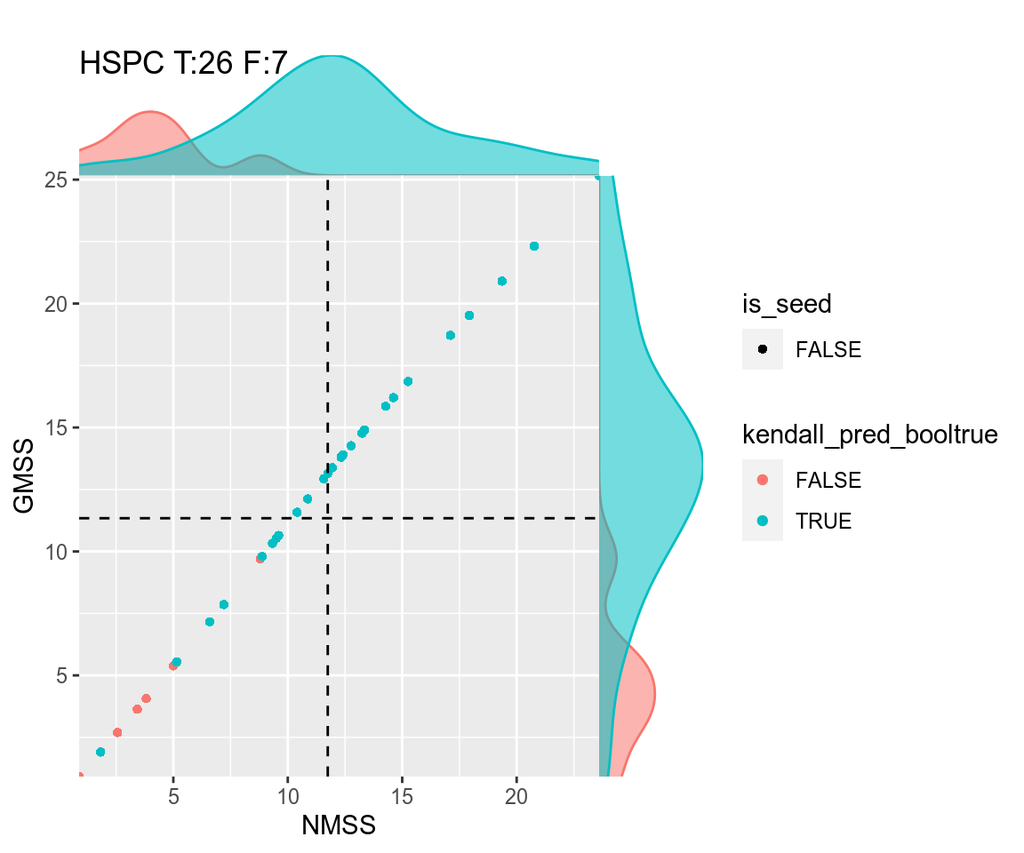

```r
AtacAnnoR:::plot_cell_distribution(cell_meta,'HSPC')
```

## Second round annotation

In the second round annotation, AtacAnnoR performs a genome-wide-level annotation of all query scATAC-seq cells using the seed cells from query itself to avoid batch effect.

### Step 1: Seed cell cleaning

Seed cell cleaning is done by applying WKNN algorithm to the seed cell candidates themselves, and discarding those with inconsistent labels.

```r
cell_meta <- seed_cleaning(cell_meta,query_nmf_embedding)
seed_meta <- cell_meta[which(cell_meta$is_seed == T),]
get_benchmark(seed_meta$true,seed_meta$kendall_pred)    # seed cell accuracy
```

```
##          accuracy    average_recall average_precision          macro_f1
##         0.9804751         0.9539367         0.9771043         0.9605386
```

`AtacAnnoR:::plot_seed_cells()` can be used to plot the seed cells on UMAP.

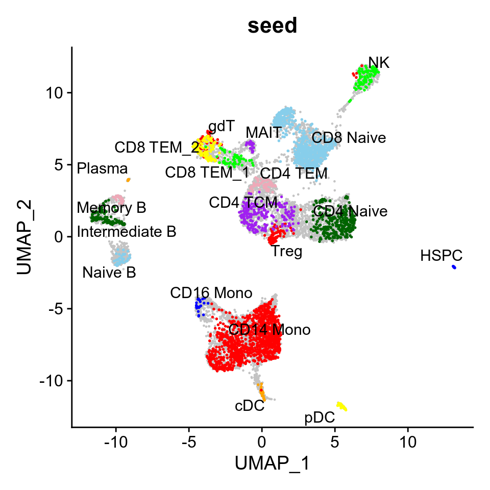

```r
AtacAnnoR:::plot_seed_cells(SeuratObj_ATAC,cell_meta)
```

### Step 2: Final prediction

Final prediction is done by applying WKNN algorithm again to predicted the left unlabeled cells using seed cells’ labels.

```r
cell_meta <- WKNN_predict(cell_meta,query_nmf_embedding)
get_benchmark(cell_meta$true,cell_meta$final_pred)    # final predictions accuracy
```

```
##          accuracy    average_recall average_precision          macro_f1
##         0.9118325         0.8869223         0.8933644         0.8875471
```

`AtacAnnoR:::plot_confusion_matrix()` can be used to plot the confusion matrix of the prediction.

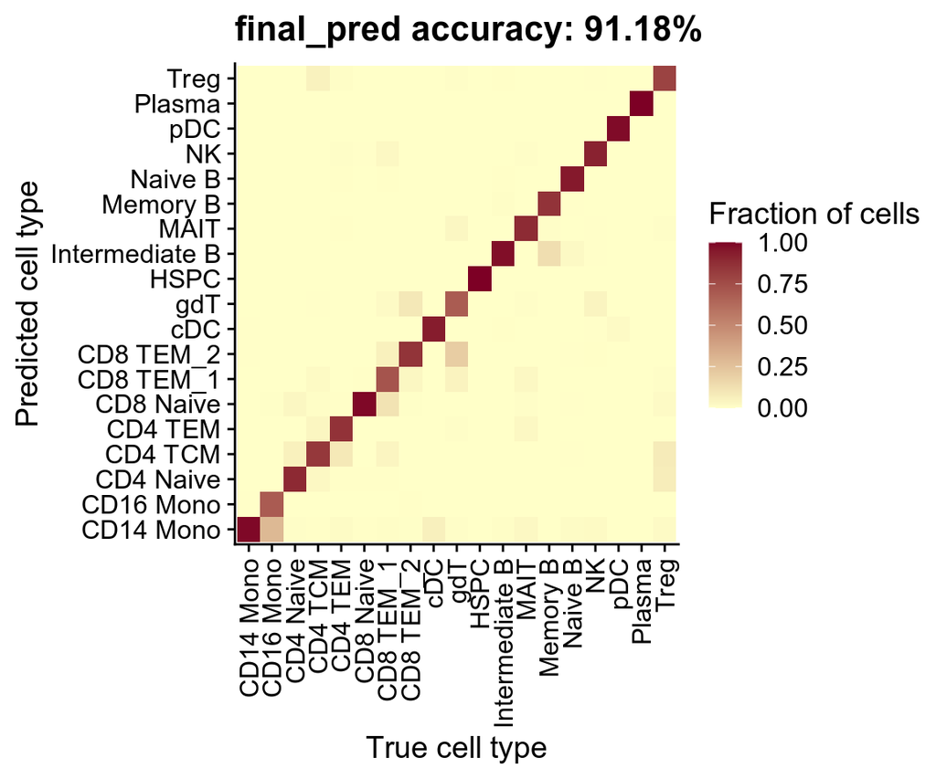

```r
AtacAnnoR:::plot_confusion_matrix(cell_meta,'final_pred')
```

Compare the AtacAnnoR’s predicted labels with the ground true labels.

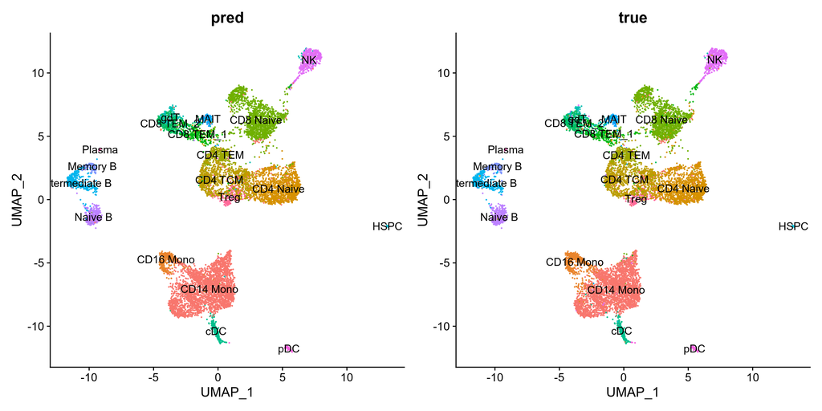

```r
SeuratObj_ATAC$pred <- cell_meta$final_pred
DimPlot(SeuratObj_ATAC,group.by = 'pred',label = T) + NoLegend() |
  DimPlot(SeuratObj_ATAC,group.by = 'true',label = T) + NoLegend()
```